# IMDb movie reviews

In this notebook, I will test the sentiment analysis models from HuggingFace on the movie reviews datset kindly provided by Maas et al. Dataset is made up of polar reviews, either very positive or very negative. For the moment, we will focus on the very positive reviews.

```python
import pandas as pd
import numpy as np
import seaborn as sns

from transformers import pipeline

sns.set()
```

Let us load the reviews into a dataframe. Since each review is stored in a $\texttt{.txt}$ file named $\texttt{[id]_[rating].txt}$ in a folder, we will extract it into a dataframe.

```python
import os

folder_path = "./sentiment-analysis-on-movie-reviews/aclImdb/test/pos"

# Get the list of files in the folder
files = os.listdir(folder_path)

# Sort files based on the id
sorted_files = sorted(files, key=lambda x: int(x.split('_')[0]))
```

```python
ratings = []
reviews = []

# Iterate through the sorted files
for file_name in sorted_files:
    _, rating = file_name.split('_')
    rating = int(rating[:-4])

    ratings.append(rating)

    # Read the contents of the file
    file_path = os.path.join(folder_path, file_name)
    with open(file_path, 'r') as file:
        review = file.read()
        reviews.append(review)
```

Let us see an example of a review

```python
reviews[0]
```

```
"I went and saw this movie last night after being coaxed to by a few friends of mine. I'll admit that I was reluctant to see it because from what I knew of Ashton Kutcher he was only able to do comedy. I was wrong. Kutcher played the character of Jake Fischer very well, and Kevin Costner played Ben …
```

```python
ratings[0]
```

```
10
```

```python
data = {'Review': reviews, 'Rating': ratings}
df_pos = pd.DataFrame(data)
```

```python
df_pos = df_pos.head(500)
df_pos
```

|  | Review | Rating |
| --- | --- | --- |
| 0 | I went and saw this movie last night after bei... | 10 |
| 1 | My boyfriend and I went to watch The Guardian.... | 10 |
| 2 | My yardstick for measuring a movie's watch-abi... | 7 |
| 3 | How many movies are there that you can think o... | 7 |
| 4 | This movie was sadly under-promoted but proved... | 10 |
| ... | ... | ... |
| 495 | Blade is probably one of the best vampire/acti... | 10 |
| 496 | Great underrated movie great action good actor... | 9 |
| 497 | I loved it. In fact, I watched it over and ove... | 9 |
| 498 | this film was brilliant! i absolutely loved it... | 10 |
| 499 | I remember seeing this one in the theatres whe... | 8 |

500 rows × 2 columns

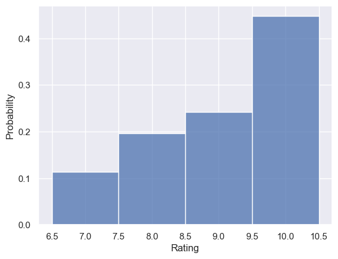

```python
sns.histplot(data=df_pos, x='Rating', discrete=True, stat='probability', )
```

## Pipeline

We will kick things off with the default model from Hugging Face. Testing the setup.

```python
sentiment_pipeline = pipeline("sentiment-analysis")
data = ["I love you", "I hate you"]
sentiment_pipeline(data)
```

```
No model was supplied, defaulted to distilbert-base-uncased-finetuned-sst-2-english and revision af0f99b (https://huggingface.co/distilbert-base-uncased-finetuned-sst-2-english).
Using a pipeline without specifying a model name and revision in production is not recommended.
```

```
[{'label': 'POSITIVE', 'score': 0.9998656511306763},
 {'label': 'NEGATIVE', 'score': 0.9991129040718079}]
```

```python
for i, row in df_pos.iterrows():
    if i > 50:
        break
    try:
        # print(row['Review'])
        sent = sentiment_pipeline(row['Review'])
        # print(sent)
        predictions.append((i, round(sent[0]['score'] * 10)))

    except:
        print(f'Broke for {i}')
```

```
Token indices sequence length is longer than the specified maximum sequence length for this model (796 > 512). Running this sequence through the model will result in indexing errors
```

```
Broke for 11
Broke for 22
Broke for 24
Broke for 31
Broke for 32
```

We will assign labels by simmply rounding the score given by the model.

```python
predictions[:10]
```

```
[(0, 10),
 (1, 10),
 (2, 7),
 (3, 10),
 (4, 10),
 (5, 9),
 (6, 10),
 (7, 10),
 (8, 10),
 (9, 10)]
```

```python
sum = 0
count_reviewed = len(predictions)
for i in range(count_reviewed):
    index = predictions[i][0]
    sum += (df_pos.iloc[index]['Rating'] == predictions[i][1])

sum/count_reviewed
```

```
0.34782608695652173
```

Notice that the default model is a rather bad way to predict the rating for a movie based off of a review, "guessing" correctly the label in only 34.8% of the cases. It is expected, since it outputs the probability of the review being positive. It is not trained to distinguish between postitive sentiment texts.

## Further work

One option is to try to fine-tune the model to the specific task at hand. We are dealing with a classification problem different from $\textit{positive}$ vs $\textit{negative}$.